# Delta Method

FW8051 Statistics for Ecologists

## Learning Objectives

Understand how we can use the delta method to calculate SEs for functions of parameters

See also:

[figure not shown]

In the GLS section, we learned how to calculate $var(\hat{\beta}_0 + X_i\hat{\beta}_1)$ using matrix multiplication:

$$\text{var}(X\beta) = X\Sigma X^T$$

where $X$ is our design matrix, $\Sigma$ is the var/cov matrix of our parameters:

$X = \begin{bmatrix} 1 & X_1\\ 1 & X_2\\ \vdots & \vdots\\ 1 & X_n\\ \end{bmatrix}$ $\Sigma = \begin{bmatrix} \sigma^2_{\hat{\beta}_0} & \sigma^2_{\hat{\beta}_0,\hat{\beta}_1}\\ \sigma^2_{\hat{\beta}_0,\hat{\beta}_1} & \sigma^2_{\hat{\beta}_1} \\ \end{bmatrix}$

- $\sigma^2_{\hat{\beta}_0}, \sigma^2_{\hat{\beta}_1}$ = variance of $\hat{\beta}_0$, $\hat{\beta}_1$, respectively
- $\sigma^2_{\hat{\beta}_0,\hat{\beta}_1}$ = covariance of $\hat{\beta}_0$ and $\hat{\beta}_1$

What if we are interested in non-linear functions of parameters?

$$Length_i = L_\infty(1-\exp(-k Age_i))$$

Options:

- Bootstrap
- Delta method
- Baysian inference

$$Length_i = L_\infty(1-\exp(-k Age_i))$$

If we estimate $\theta =(L_\infty, k)$ using Maximum likelihood, and our sample size is large, we know:

$$\hat{\theta} \sim MVN(\theta, I^{-1}(\theta)) \text{ with: }$$

- I($\theta) = \left[\frac{\partial^2 logL(\theta)}{\partial \theta^2}\right]$ is the Hessian matrix

What if we want to calculate a confidence interval for the length at a particular age, $Age_i$:

$f(\hat{L}_\infty, \hat{k}) = var(\hat{L}_\infty(1-\exp(-\hat{k} Age_i)))$

## Delta Method

Let:

- $f(L_\infty, k) = L_\infty(1-\exp(-k Age_i))$
- $f'(L_\infty, k) = (\frac{\partial f}{\partial L_\infty}, \frac{\partial f}{\partial k})$
- $\Sigma$ be the asympototic variance/covariance matrix of $(L_\infty, k)$ given by the inverse of the Hessian matrix

**Delta Method** (derived using a Taylor’s series approximation of $f$):

$var(\hat{L}_\infty(1-\exp(-\hat{k} Age_i))) \approx f'(\hat{L}_\infty, \hat{k})\Sigma f'(L_\infty, k)^T|_{L_\infty = \hat{L}_\infty, k=\hat{k}}$

More generally:

$var(f(\theta)) \approx f'(\theta)\Sigma f'(\theta)^T |_{\theta=\hat{\theta}}$

## Implementation

In R:

- use the `detavar` function in the `emdbook` package to calculate the derivatives and variance (see `FemalesvonB.R`)
- or, calculate the derivatives yourself (or using https://www.symbolab.com/solver/derivative-calculator), then roll your own with `%*%` for matrix multiplication.

$f(\theta) = L_\infty(1-\exp(-k Age_i))$

$f'(\theta) = (1-\exp(-k Age_i), L_\infty Age_i \exp(-kAge_i))$

## Derivatives

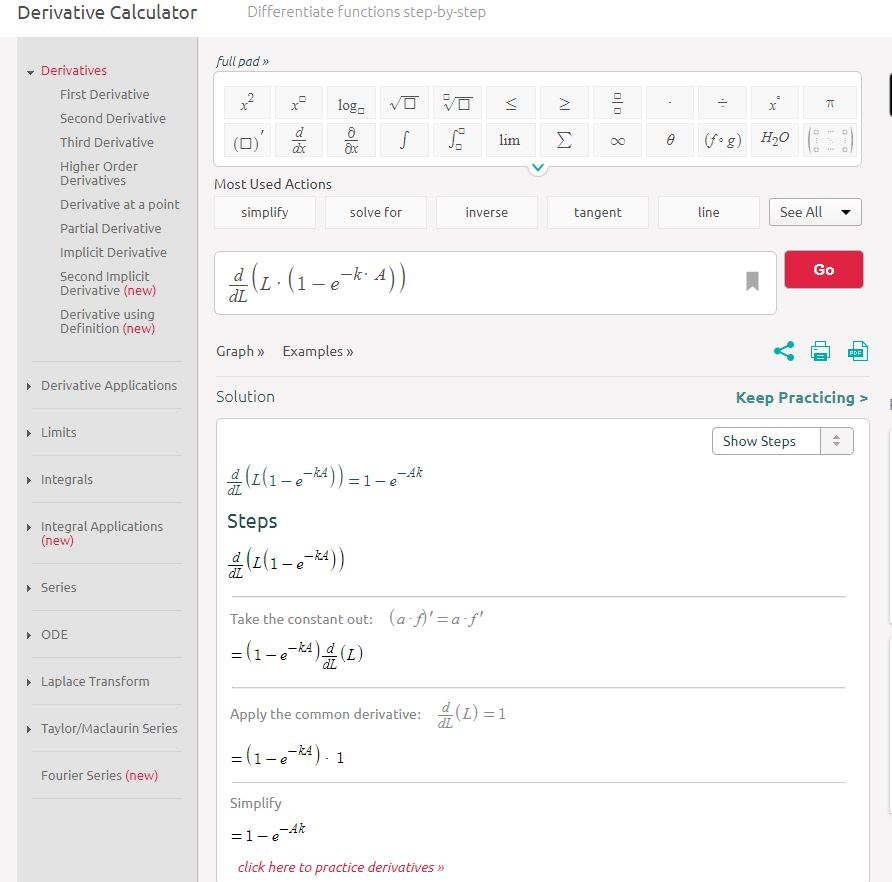